# ML Entrepreneurship - Project 3

Creating the Paywalled Stock Market Prediction Service

## Upated November 2019 - Includes new historical repo, new fundamental repo, Keras TF 2.x model

### What's Our Goal?

In our final ML-to-WebApp project, we will create a stock market prediction application behind a real paywall service. We will apply the power of TensorFlow, a high-performance numerical computation framework, on stock market data to offer predictions of future prices.

In this hypothetical application, viewers will have to purchase subscriptions for your service through the powerful web plugin Memberful.com. This is a critical point I can't emphasize enough, whenever you are dealing with sensitive data that isn't your main business, push that work onto others that do specialize in it. The last thing you want is to be responsible for stolen customer data. Here, I will show you a great way to monetize your business without unnecessary risks in a fully professional ecosystem.

### Five Year's of S&P 500 Data

Let's download some financial stock data from Kaggle's open data sources. The dataset holds stock market end-of-day prices and corollary data for stocks of the S&P 500 over a period of 5 years.

```python
import pandas as pd
import matplotlib.pyplot as plt
import matplotlib
import datetime, random
import numpy as np; np.random.seed(0)
import warnings
import itertools, os
from zipfile import ZipFile
from urllib.request import urlopen
from io import BytesIO
warnings.filterwarnings('ignore')

# Load locally
local = False

if not local:
    # this will download a copy from GitHub and save it locally
    URL = 'https://github.com/amunategui/amunategui.github.io/raw/master/all_stocks_5yr.zip'
    z = urlopen(URL)
    myzip = ZipFile(BytesIO(z.read())).extract('all_stocks_5yr.csv')
    stocks_df = pd.read_csv(myzip)
    stocks_df.head()
else:
    # read locally saved version
    stocks_df = pd.read_csv('all_stocks_5yr.csv')
```

```python
stocks_df.head()
```

|  | date | open | high | low | close | volume | Name |
| --- | --- | --- | --- | --- | --- | --- | --- |
| 0 | 2013-02-08 | 15.07 | 15.12 | 14.63 | 14.75 | 8407500 | AAL |
| 1 | 2013-02-11 | 14.89 | 15.01 | 14.26 | 14.46 | 8882000 | AAL |
| 2 | 2013-02-12 | 14.45 | 14.51 | 14.10 | 14.27 | 8126000 | AAL |
| 3 | 2013-02-13 | 14.30 | 14.94 | 14.25 | 14.66 | 10259500 | AAL |
| 4 | 2013-02-14 | 14.94 | 14.96 | 13.16 | 13.99 | 31879900 | AAL |

## Prepare the stock market data

Let's use 5 periods of trading market and predict 5 days out (and please experiment with those settings).

```python
stock_symbols = list(set(stocks_df['Name']))

# build dataset
X = []
y = []
symbols = []
prediction_dates = []
last_market_dates = []

# rolling predictions
rolling_period = 5
predict_out_period = 5

for stock in stock_symbols:
    print(stock)
    stock_data = stocks_df[stocks_df['Name']==stock].copy()

    for per in range(rolling_period, len(stock_data)-predict_out_period):
        X_tmp = []
        y_tmp = 0
        for rollper in range(per-rolling_period,per):
            # build the 'features'
            X_tmp += [np.log(stock_data['close'].values[rollper])]

        X.append(np.array(X_tmp))
        # build 'labels'
        y.append(np.log(stock_data['close'].values[per + predict_out_period]))
        prediction_dates.append(stock_data['date'].values[per + predict_out_period])
        last_market_dates.append(stock_data['date'].values[per])
        symbols.append(stock)


stock_model_ready_df = pd.DataFrame(X)
stock_model_ready_df.columns = [str(f) for f in list(stock_model_ready_df)]

stock_model_ready_df['outcome'] = y
stock_model_ready_df['date'] = prediction_dates
stock_model_ready_df['last_market_date'] = last_market_dates
stock_model_ready_df['symbol'] = symbols
stock_model_ready_df.tail()

# write a copy to file to use in our web application
stock_model_ready_df.to_csv('stock_market_historical_data.csv', index=None)
```

```
WYNN
ITW
NKE
CMS
HOG
SNPS
LOW
INCY
CSX
VNO
XRAY
MYL
IR
PFG
CAG
NCLH
COTY
KORS
LH
DHR
HP
QCOM
CTXS
GPN
VZ
CBS
PSA
AMAT
NFLX
XEL
PEP
BAC
PKG
MLM
HCA
RCL
PBCT
DFS
ADSK
EXPE
```

[output cut: 450 more lines]

```
PAYX
CF
ZTS
HBAN
MAS
PFE
WAT
DWDP
NUE
RE
CMG
RTN
IQV
NI
JEC
```

## Log Transform

Helping the model understand the data by normalizing it

```python
values = [199,45,5]
np.log(values)
```

```
array([5.29330482, 3.80666249, 1.60943791])
```

```python
np.exp(np.log(values))
```

```
array([199.,  45.,   5.])
```

### Live Data - Focus on just one stock to keep things simple

```python
# loop the amount of days we don't have an outome
stock_data_live = stocks_df[stocks_df['Name']=='AAPL'].copy()
no_outcome_id = len(stock_data_live)-predict_out_period
future_data = []
prediction_dates = []
last_market_dates = []

# shift everything out into 'no outcome' zone
for per in range(no_outcome_id+1, len(stock_data_live)+1):
    X_tmp = []
    y_tmp = 0
    for rollper in range(per-rolling_period,per):
        X_tmp += [np.log(stock_data_live['close'].values[rollper])]

    future_data.append(np.array(X_tmp))
    last_market_dates.append(stock_data_live['date'].values[rollper])
    # create a business day offset for future dates to avoid weekends and holidays
    prediction_dates.append(np.busday_offset(np.datetime64(stock_data_live['date'].values[rollper],'D'),predict_out_period, roll='forward'))

future_model_ready_df = pd.DataFrame(future_data)
future_model_ready_df.columns = [str(f) for f in list(future_model_ready_df)]

# outcome here is just a random placeholder, it won't be used
future_model_ready_df['outcome'] = -1
future_model_ready_df['date'] = prediction_dates
future_model_ready_df['last_market_date'] = last_market_dates
future_model_ready_df.head()
```

|  | 0 | 1 | 2 | 3 | 4 | outcome | date | last_market_date |
| --- | --- | --- | --- | --- | --- | --- | --- | --- |
| 0 | 5.144642 | 5.123726 | 5.117814 | 5.120565 | 5.122654 | -1 | 2018-02-08 | 2018-02-01 |
| 1 | 5.123726 | 5.117814 | 5.120565 | 5.122654 | 5.078294 | -1 | 2018-02-09 | 2018-02-02 |
| 2 | 5.117814 | 5.120565 | 5.122654 | 5.078294 | 5.052992 | -1 | 2018-02-12 | 2018-02-05 |
| 3 | 5.120565 | 5.122654 | 5.078294 | 5.052992 | 5.093934 | -1 | 2018-02-13 | 2018-02-06 |
| 4 | 5.122654 | 5.078294 | 5.052992 | 5.093934 | 5.072295 | -1 | 2018-02-14 | 2018-02-07 |

You will need to install TensorFlow: https://www.tensorflow.org/install/

## Tensorflow 2.x, Keras, and Regression

https://www.tensorflow.org/tutorials/keras/regression

```python
FEATURES = [f for f in list(stock_model_ready_df) if f not in ['outcome' ]]

MODEL_FEATURES = [f for f in list(stock_model_ready_df) if f not in ['outcome','date', 'last_market_date', 'symbol' ]]
LABEL = "outcome"

# available features without outcome
print('FEATURES', FEATURES)

# model-ready features
print('MODEL_FEATURES', MODEL_FEATURES)
```

```
FEATURES ['0', '1', '2', '3', '4', 'date', 'last_market_date', 'symbol']
MODEL_FEATURES ['0', '1', '2', '3', '4']
```

```python
import tensorflow as tf
from tensorflow.keras.models import Sequential
from tensorflow.keras.layers import Dense
from tensorflow.keras.models import model_from_json

# fix random seed for reproducibility
np.random.seed(7)

from sklearn.model_selection import train_test_split
# Train and Test
x_train, x_test, y_train, y_test = train_test_split(stock_model_ready_df[FEATURES],
                         stock_model_ready_df[LABEL], test_size=0.33, random_state=42)

model = Sequential()
model.add(Dense(5, activation='relu', input_dim=5))
model.add(Dense(5, activation='relu'))
model.add(Dense(1, kernel_initializer='normal'))
model.compile(loss='mean_squared_error', optimizer='adam')


# Fit the model
model.fit(x_train[MODEL_FEATURES], y_train, epochs=3, batch_size=5, verbose=1)
```

```
<tensorflow.python.keras.callbacks.History at 0x12dac3d30>
```

```python
# evaluate the model
scores = model.evaluate(x_test[MODEL_FEATURES], y_test, verbose=0)
print("%s: %.2f%%" % (model.metrics_names[0], scores*100))

# serialize model to JSON
model_json = model.to_json()
with open("model.json", "w") as json_file:
    json_file.write(model_json)
# serialize weights to HDF5
model.save_weights("model.h5")
print("Saved model to disk")
```

```
loss: 0.18%
Saved model to disk
```

```python
# deserialize the model
# load json and create model
json_file = open('model.json', 'r')
loaded_model_json = json_file.read()
json_file.close()
loaded_model = model_from_json(loaded_model_json)
# load weights into new model
loaded_model.load_weights("model.h5")
print("Loaded model from disk")
```

```
Loaded model from disk
```

```python
# evaluate loaded model on test data
loaded_model.compile(loss='mean_squared_error', optimizer='adam')
score = loaded_model.evaluate(x_test[MODEL_FEATURES], y_test, verbose=0)
print("%s: %.2f%%" % (loaded_model.metrics_names[0], score*100))
```

```
loss: 0.18%
```

```python
!pwd
```

```
/Users/manuel/Desktop/enterprise-stock-fix
```

```python
# predictions have to be restored for processing
x_evaluate_tmp = stock_model_ready_df.copy()
x_evaluate_tmp = x_evaluate_tmp[x_evaluate_tmp['symbol'] == 'AAPL']

predictions = loaded_model.predict(x_evaluate_tmp[MODEL_FEATURES])
predictions
```

```
array([[4.2172985],
       [4.2151375],
       [4.205891 ],
       ...,
       [5.1665335],
       [5.1554723],
       [5.1463604]], dtype=float32)
```

```
301347    4.147207
301348    4.161045
301349    4.151196
301350    4.144041
301351    4.118967
301352    4.094463
301353    4.120530
301354    4.107735
301355    4.119227
301356    4.121866
Name: outcome, dtype: float64
RMSE: (+/- off) 0.0393478755781353
```

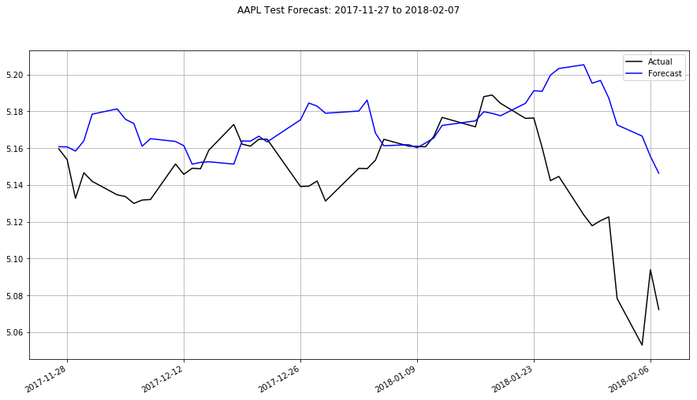

```python
actuals = x_evaluate_tmp['outcome']
forecasts =  [ item for elem in predictions.tolist() for item in elem]
print(actuals[0:10])

from sklearn.metrics import mean_squared_error
print('RMSE: (+/- off)', np.sqrt(mean_squared_error(list(actuals), forecasts)))

x_done = x_evaluate_tmp.copy()
x_done['forcast'] = forecasts

x_done = x_done.sort_values('date')
x_done = x_done.tail(50)
x_done['date'] = pd.to_datetime(x_done['date'])

fig, ax = plt.subplots(figsize=(15,8))
plt.suptitle('AAPL Test Forecast: ' + str(np.min(x_done['date']))[:10] + ' to '+ str(np.max(x_done['date']))[:10])
plt.plot(x_done['date'] , x_done['outcome'],  color='black', label='Actual')
plt.plot(x_done['date'] , x_done['forcast'],  color='blue', label='Forecast')
plt.legend()
plt.grid()
plt.xticks(rotation='vertical')
ax.xaxis_date()
fig.autofmt_xdate()
plt.show()
```

## Forecast on live data (basically the last x days where we don't have an outcome...)

```
2018-02-07 00:00:00
```

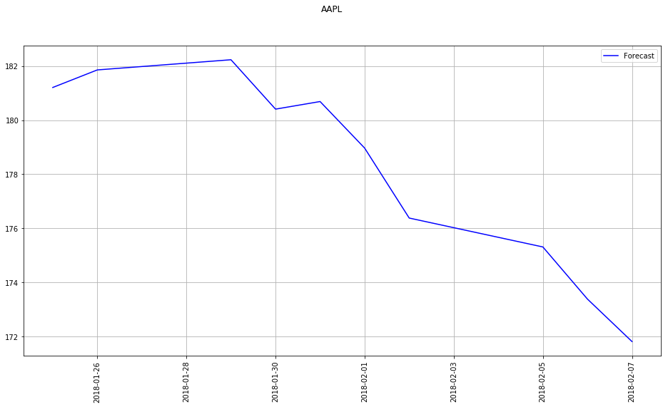

```python
# forecast on live data (basically the last x days where we don't have an outcome...)
predictions = loaded_model.predict(x_evaluate_tmp[MODEL_FEATURES])
forecasts =  [ item for elem in predictions.tolist() for item in elem]

future_df_tmp = x_evaluate_tmp.copy()
future_df_tmp['forcast'] = np.exp(forecasts)
future_df_tmp['date'] = pd.to_datetime(future_df_tmp['date'])

print(np.max(future_df_tmp['date']))
future_df_tmp = future_df_tmp.tail(10)

future_df_tmp = future_df_tmp.sort_values('date')

fig, ax = plt.subplots(figsize=(16, 8))
plt.suptitle('AAPL')
plt.plot(future_df_tmp['date'], future_df_tmp['forcast'], color='blue', label='Forecast')
plt.legend()
plt.grid()
plt.xticks(rotation='vertical')
plt.show()
```

```python
future_df_tmp
```

|  | 0 | 1 | 2 | 3 | 4 | outcome | date | last_market_date | symbol | forcast |
| --- | --- | --- | --- | --- | --- | --- | --- | --- | --- | --- |
| 302586 | 5.160721 | 5.166385 | 5.176658 | 5.171563 | 5.187944 | 5.142307 | 2018-01-25 | 2018-01-18 | AAPL | 181.208514 |
| 302587 | 5.166385 | 5.176658 | 5.171563 | 5.187944 | 5.188837 | 5.144642 | 2018-01-26 | 2018-01-19 | AAPL | 181.858594 |
| 302588 | 5.176658 | 5.171563 | 5.187944 | 5.188837 | 5.184364 | 5.123726 | 2018-01-29 | 2018-01-22 | AAPL | 182.235509 |
| 302589 | 5.171563 | 5.187944 | 5.188837 | 5.184364 | 5.176150 | 5.117814 | 2018-01-30 | 2018-01-23 | AAPL | 180.407397 |
| 302590 | 5.187944 | 5.188837 | 5.184364 | 5.176150 | 5.176376 | 5.120565 | 2018-01-31 | 2018-01-24 | AAPL | 180.688487 |
| 302591 | 5.188837 | 5.184364 | 5.176150 | 5.176376 | 5.160319 | 5.122654 | 2018-02-01 | 2018-01-25 | AAPL | 178.965391 |
| 302592 | 5.184364 | 5.176150 | 5.176376 | 5.160319 | 5.142307 | 5.078294 | 2018-02-02 | 2018-01-26 | AAPL | 176.375970 |
| 302593 | 5.176150 | 5.176376 | 5.160319 | 5.142307 | 5.144642 | 5.052992 | 2018-02-05 | 2018-01-29 | AAPL | 175.306079 |
| 302594 | 5.176376 | 5.160319 | 5.142307 | 5.144642 | 5.123726 | 5.093934 | 2018-02-06 | 2018-01-30 | AAPL | 173.377670 |
| 302595 | 5.160319 | 5.142307 | 5.144642 | 5.123726 | 5.117814 | 5.072295 | 2018-02-07 | 2018-01-31 | AAPL | 171.805049 |

```python
future_df_tmp['forcast'].values[-1]
```

```
171.80504889628833
```

```python
### Let's get a better output with clear forecast markers
```

[output not shown]

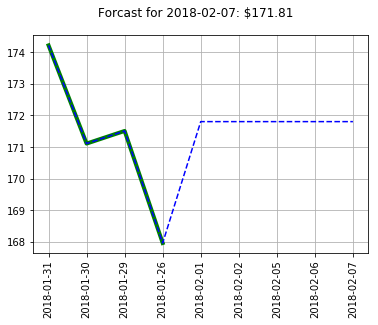

```python
actuals = list(future_df_tmp.tail(1).values[0])[0:predict_out_period-1]
# transform log price to price of past data
actuals = list(np.exp(actuals))
days_before = future_df_tmp['last_market_date'].values[-1]
days_before_list = []
for d in range(rolling_period-1):
    days_before_list.append(str(np.busday_offset(np.datetime64(days_before,'D'),-d, roll='backward')))

plt.plot(days_before_list, actuals, color='green', linewidth=4)

for d in range(1, predict_out_period+1):
    days_before_list.append(str(np.busday_offset(np.datetime64(days_before,'D'),d, roll='forward')))
    actuals.append(future_df_tmp['forcast'].values[-1])


plt.suptitle('Forcast for ' + str(future_df_tmp['date'].values[-1])[0:10] + ': $' + str(np.round(future_df_tmp['forcast'].values[-1],2)))
plt.plot(days_before_list, actuals, color='blue', linestyle='dashed')
plt.grid()
plt.xticks(days_before_list, days_before_list, rotation='vertical')
```

## Creating our local Flask web application

It's time to wrap up our code into a Flask appliction. Let's abstract our code into usable functions to make our deployment that much easier.

Let's create a live set of market points (basically the last trading period for each stock) and save it to file so our web users can get future predictions.

```python
stock_market_live_data = []
for stock in stock_symbols:
    print(stock)
    stock_data = stocks_df[stocks_df['Name']==stock].copy()
    # get only the last rolling_period
    stock_data = stock_data.tail(rolling_period)

    no_outcome_id = len(stock_data)-predict_out_period
    future_data = []
    future_dates = []
    last_market_dates = []
    # shift everything out into 'no outcome' zone
    for per in range(no_outcome_id+1, len(stock_data)+1):
        X_tmp = []
        y_tmp = 0
        for rollper in range(per-rolling_period,per):
            X_tmp +=[ np.log(stock_data['close'].values[rollper])]

        future_data.append(np.array(X_tmp))
        last_market_dates.append(stock_data['date'].values[rollper])
        # create a business day offset for future dates to avoid weekends and holidays
        future_date = np.busday_offset(np.datetime64(stock_data['date'].values[rollper],'D'),predict_out_period, roll='forward')

    stock_market_live_data.append(X_tmp + [-1] + [str(future_date)] + [stock_data['date'].values[rollper]] + [stock])

stock_market_live_data = pd.DataFrame(stock_market_live_data)
stock_market_historical_data = pd.read_csv('stock_market_historical_data.csv')
stock_market_live_data.columns = list(stock_market_historical_data)
# write a copy to file to use in our web application
stock_market_live_data.to_csv('stock_market_live_data.csv', index=None)
```

```
WYNN
ITW
NKE
CMS
HOG
SNPS
LOW
INCY
CSX
VNO
XRAY
MYL
IR
PFG
CAG
NCLH
COTY
KORS
LH
DHR
HP
QCOM
CTXS
GPN
VZ
CBS
PSA
AMAT
NFLX
XEL
PEP
BAC
PKG
MLM
HCA
RCL
PBCT
DFS
ADSK
EXPE
```

[output cut: 450 more lines]

```
PAYX
CF
ZTS
HBAN
MAS
PFE
WAT
DWDP
NUE
RE
CMG
RTN
IQV
NI
JEC
```

```python
stock_market_live_data.head()
```

|  | 0 | 1 | 2 | 3 | 4 | outcome | date | last_market_date | symbol |
| --- | --- | --- | --- | --- | --- | --- | --- | --- | --- |
| 0 | 5.138677 | 5.115356 | 5.108850 | 5.095099 | 5.177956 | -1 | 2018-02-14 | 2018-02-07 | WYNN |
| 1 | 5.153754 | 5.138031 | 5.082149 | 5.100720 | 5.096446 | -1 | 2018-02-14 | 2018-02-07 | ITW |
| 2 | 4.214347 | 4.207971 | 4.164958 | 4.177766 | 4.184033 | -1 | 2018-02-14 | 2018-02-07 | NKE |
| 3 | 3.787819 | 3.772301 | 3.754901 | 3.741472 | 3.741472 | -1 | 2018-02-14 | 2018-02-07 | CMS |
| 4 | 3.885268 | 3.860730 | 3.837299 | 3.884035 | 3.881151 | -1 | 2018-02-14 | 2018-02-07 | HOG |

```python
import os

ROLLING_PERIOD = 5
PREDICT_OUT_PERIOD = 5
BASE_DIR = ''
FEATURES = [str(id) for id in range(0,ROLLING_PERIOD)]

stock_market_historical_data = None
stock_market_live_data = None
predict_fn = None
saved_regression_model_path ='model.json'
saved_model_weights_path = "model.h5"

def prepare_data():
    global stock_market_historical_data, stock_market_live_data, predict_fn

    # deserialize the model
    json_file = open(saved_regression_model_path, 'r')
    loaded_model_json = json_file.read()
    json_file.close()
    predict_fn = model_from_json(saved_regression_model_path)
    # load weights into new model
    predict_fn.load_weights(saved_model_weights_path)

    stock_market_historical_data = pd.read_csv(os.path.join(BASE_DIR, 'stock_market_historical_data.csv'))
    stock_market_live_data = pd.read_csv(os.path.join(BASE_DIR, 'stock_market_live_data.csv'))


prepare_data()
stock_market_live_data.head()
```

|  | 0 | 1 | 2 | 3 | 4 | outcome | date | last_market_date | symbol |
| --- | --- | --- | --- | --- | --- | --- | --- | --- | --- |
| 0 | 5.138677 | 5.115356 | 5.108850 | 5.095099 | 5.177956 | -1 | 2018-02-14 | 2018-02-07 | WYNN |
| 1 | 5.153754 | 5.138031 | 5.082149 | 5.100720 | 5.096446 | -1 | 2018-02-14 | 2018-02-07 | ITW |
| 2 | 4.214347 | 4.207971 | 4.164958 | 4.177766 | 4.184033 | -1 | 2018-02-14 | 2018-02-07 | NKE |
| 3 | 3.787819 | 3.772301 | 3.754901 | 3.741472 | 3.741472 | -1 | 2018-02-14 | 2018-02-07 | CMS |
| 4 | 3.885268 | 3.860730 | 3.837299 | 3.884035 | 3.881151 | -1 | 2018-02-14 | 2018-02-07 | HOG |

## Let's abstract a prediction function

```python
def get_stock_prediction(symbol):

    temp_df = stock_market_live_data[stock_market_live_data['symbol']==symbol]

    # forecast on live data (basically the last x days where we don't have an outcome...)
    predictions = loaded_model.predict(x_evaluate_tmp[MODEL_FEATURES])
    forecasts =  [ item for elem in predictions.tolist() for item in elem]

    return(forecasts)


# run a prediction test
predictions = get_stock_prediction('MSFT')
np.exp(predictions)
```

```
array([ 67.84994039,  67.70347322,  67.08034851, ..., 175.3060792 ,
       173.37766999, 171.8050489 ])
```

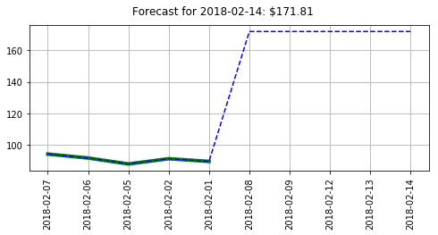

```python
# create a plot to display
def get_plot_prediction(symbol):

    predictions = get_stock_prediction(symbol)

    if (len(predictions) > 0):
        temp_df = stock_market_live_data[stock_market_live_data['symbol']==symbol]

        actuals = list(temp_df[FEATURES].values[0])
        # transform log price to price of past data
        actuals = list(np.exp(actuals))

        days_before = temp_df['last_market_date'].values[-1]
        days_before_list = []
        for d in range(ROLLING_PERIOD):
            days_before_list.append(str(np.busday_offset(np.datetime64(days_before,'D'),-d, roll='backward')))

        fig, ax = plt.subplots(figsize=(8,3))
        plt.plot(days_before_list, actuals, color='green', linewidth=4)

        for d in range(1, PREDICT_OUT_PERIOD+1):
            days_before_list.append(str(np.busday_offset(np.datetime64(days_before,'D'),d, roll='forward')))
            actuals.append(np.exp(predictions[-1]))

        plt.suptitle('Forecast for ' + str(temp_df['date'].values[-1])[0:10] + ': $' +
                     str(np.round(np.exp(predictions[-1]),2)))

        plt.plot(days_before_list, actuals, color='blue', linestyle='dashed')
        plt.grid()
        plt.xticks(days_before_list, days_before_list, rotation='vertical')
        plt.show()

get_plot_prediction('MSFT')
```

## Get Fundamental Financial Company Data from Nasdaq and Wikipedia

We'll be files from NASDAQ (source: https://www.nasdaq.com/screening/companies-by-industry.aspx)

```python
# load nasdaq corollary material
stock_company_info_amex = None
stock_company_info_nasdaq = None
stock_company_info_nyse = None

def load_fundamental_company_info():
    global stock_company_info_amex, stock_company_info_nasdaq, stock_company_info_nyse
    import pandas as pd
    stock_company_info_amex = pd.read_csv('stock_company_info_amex.csv')

    stock_company_info_nasdaq = pd.read_csv('stock_company_info_nasdaq.csv')

    stock_company_info_nyse = pd.read_csv('stock_company_info_nyse.csv')

load_fundamental_company_info()
```

```python
stock_company_info_amex.head()
```

|  | Symbol | Name | LastSale | MarketCap | ADR TSO | IPOyear | Sector | Industry | Summary Quote | Unnamed: 9 |
| --- | --- | --- | --- | --- | --- | --- | --- | --- | --- | --- |
| 0 | XXII | 22nd Century Group, Inc | 2.81 | 3.494935e+08 | NaN | NaN | Consumer Non-Durables | Farming/Seeds/Milling | https://www.nasdaq.com/symbol/xxii | NaN |
| 1 | FAX | Aberdeen Asia-Pacific Income Fund Inc | 4.14 | 1.042994e+09 | NaN | 1986.0 | NaN | NaN | https://www.nasdaq.com/symbol/fax | NaN |
| 2 | IAF | Aberdeen Australia Equity Fund Inc | 6.05 | 1.375911e+08 | NaN | NaN | NaN | NaN | https://www.nasdaq.com/symbol/iaf | NaN |
| 3 | AEF | Aberdeen Emerging Markets Equity Income Fund, ... | 6.83 | 4.132084e+08 | NaN | NaN | NaN | NaN | https://www.nasdaq.com/symbol/aef | NaN |
| 4 | FCO | Aberdeen Global Income Fund, Inc. | 8.42 | 7.346272e+07 | NaN | 1992.0 | NaN | NaN | https://www.nasdaq.com/symbol/fco | NaN |

```python
def get_fundamental_information(symbol):
    CompanyName = "No company name"
    Sector = "No sector"
    Industry = "No industry"
    MarketCap = "No market cap"
    Exchange = 'No exchange'

    if (symbol in list(stock_company_info_nasdaq['Symbol'])):
        data_row = stock_company_info_nasdaq[stock_company_info_nasdaq['Symbol'] == symbol]
        CompanyName = data_row['Name'].values[0]
        Sector = data_row['Sector'].values[0]
        Industry = data_row['Industry'].values[0]
        MarketCap = data_row['MarketCap'].values[0]
        Exchange = 'NASDAQ'

    elif (symbol in list(stock_company_info_amex['Symbol'])):
        data_row = stock_company_info_amex[stock_company_info_amex['Symbol'] == symbol]
        CompanyName = data_row['Name'].values[0]
        Sector = data_row['Sector'].values[0]
        Industry = data_row['Industry'].values[0]
        MarketCap = data_row['MarketCap'].values[0]
        Exchange = 'AMEX'

    elif (symbol in list(stock_company_info_nyse['Symbol'])):
        data_row = stock_company_info_nyse[stock_company_info_nyse['Symbol'] == symbol]
        CompanyName = data_row['Name'].values[0]
        Sector = data_row['Sector'].values[0]
        Industry = data_row['Industry'].values[0]
        MarketCap = data_row['MarketCap'].values[0]
        Exchange = 'NYSE'

    return (CompanyName, Sector, Industry, MarketCap, Exchange)

fundamentals = get_fundamental_information('AAPL')
fundamentals
```

```
('Apple Inc.',
 'Technology',
 'Computer Manufacturing',
 1054710940620.0,
 'NASDAQ')
```

```python
# !sudo pip3 install wikipedia
def get_wikipedia_intro(symbol):
    import wikipedia
    company_name = get_fundamental_information(symbol)[0]
    description = wikipedia.page(company_name).content
    return(description.split('\n')[0])

get_wikipedia_intro('AAPL')
```

```
"Apple Inc. is an American multinational technology company headquartered in Cupertino, California, that designs, develops, and sells consumer electronics, computer software, and online services. It is considered one of the Big Four tech companies along with Amazon, Google, and Facebook.The company'…
```

# Time to build our web application - Part 1

In part 1, we will build our web application without worrying about the paywall piece (we'll build it in part 2).

Under "stock-market-predictor" copy and paste the following code into a new file called "main.py":

### Flask Web Application Files

To get everything setup accrodingly, create a folder called "stock-market-predictor", another underneath called "static" and "templates".

Under "stock-market-predictor" copy and paste the following code into a new file called "main.py":

# Flask main.py file

[output not shown]

## Under the project root folder, create a new folder called 'templates' and paste the following in 'stock-market-report.html':

```
<!DOCTYPE html>
    <html>
    <head>
        <meta name="viewport" content="width=device-width, initial-scale=1">
        <meta charset="UTF=8">
        <title>Stock Market Predictor Service</title>
        <script src="//ajax.googleapis.com/ajax/libs/jquery/3.3.1/jquery.min.js"></script>
      <link rel="stylesheet" href="//netdna.bootstrapcdn.com/bootstrap/3.0.3/css/bootstrap-theme.min.css">
        <link rel="stylesheet" href="//netdna.bootstrapcdn.com/bootstrap/3.0.3/css/bootstrap.min.css">
        <script src="//netdna.bootstrapcdn.com/bootstrap/3.0.3/js/bootstrap.min.js"></script>
    </head>

    <body style = "background-color: black; padding-top: 10px; ">
          <div class="container">
            <div class="navbar-header">
              <table cellpadding ="5" style="width:700px; background-color:white;">
                <tr>
                  <td>
                       <img src="static/images/forecast-chart.png" alt="forecast chart" height="79" width="215">
                  </td>
                  <td>
                      <H2><p style="text-align:center">STOCK MARKET PREDICTOR</p></H2>
                  </td>
                   <td>
                     <img src="static/images/forecast-chart.png" alt="forecast chart" height="79" width="215">

                  </td>
                </tr>
            </div>
          </div>


         <div class="container">

          <table border=0 cellpadding="10" style="width: 700px; background-color:lightgrey;">
            <tr>
              <td colspan='2'><label>Select the stock you would like to forecast:</label>
                <FORM id='submit_content' method="POST" action="{{ url_for('get_financial_information') }}">
                  <SELECT class="selectpicker" name="selected_stock" onchange="this.form.submit()">
                      <option value="{{selected_stock}}" selected>{{selected_stock}}</option>
                   {% for stock in options_stocks %}
                       <option>{{stock}}</option>
                   {% endfor %}
                </SELECT>
                </FORM>
              </td>
            </tr>
            <tr>
              <td>{{chart_plot}}</td>
              <td>
                  {{fundamentals_company_name}}
                  {{fundamentals_sector}}
                  {{fundamentals_industry}}
                  {{fundamentals_marketcap}}
                  {{fundamentals_exchange}}
              {{wiki}}</td>
            </tr>
          </table>
        </div>
    </body>
    </html>
```

```python
from IPython.display import Image
Image(filename="forecast-chart.png")
```

[output not shown]

We also need to copy our TensorFlow/Keras saved model and weights. Find you latest ones fron you work folder and copy the content under it directly under "stock-market-predictor" folder (I included mine in the downloads file just in case you want to use them).

You web-application folder should look like:

```
stock-market-predictor
├── main.py
├── stock_market_live_data.csv
├── stock_market_historical_data.csv
├── stock_company_info_nyse.csv
├── stock_company_info_nasdaq.csv
├── stock_company_info_amex.csv
├── model.h5
├── model.json
├── templates
    └── stock-market-report.html
├── static
    └── images
        └── forecast-chart.png
```

That's it, let's take this for a local spin!

## That's it, let's take this for a local spin!

pip3 install wikipedia --user pip3 install tensorflow --user

Follow the video for the rest of the upload and build information.

Best!